# Lab VS Interactions

Adam Dziorny

November 29, 2017

## Overview

In this markdown we will look at patients with hemoglobins that resulted less than a given value, defined as patients with anemia. We will then examine HR values for those patients from the most recent flowsheet record to that lab result. This requires joining the lab result data frame with the HR VS data frame, as well as the cohort data frame (to obtain the patient age).

First we load the required libraries:

```r
library(ggplot2)
library(dplyr)
library(RCurl)
```

Load the pre-processed lab data and the VS HR data:

```r
load('D_preprocessed')
load('D_vs_hr')
```

### Summarize

First we limit the lab data to only hemoglobin values from a CBC w/ or w/o diff:

```r
hgb.df <-
  labs.df %>%
  #dplyr::filter(PROC_NM %in% c('CBC w Diff','CBC wo Diff')) %>%
  dplyr::filter(BASE_NM == 'hgb') %>%
  dplyr::filter(VALUE < 1000)

cat(sprintf('Number of rows: %0.f\n',
            nrow(hgb.df)))
```

```
## Number of rows: 292306
```

To begin, we will use a cutoff HGB of 7.0 g/dL. How many rows will this leave us with:

```r
hgb.filt.df <-
  hgb.df %>%
  dplyr::filter(VALUE <= 7.0)

cat(sprintf('Number of rows with Hgb < 7 g/dL: %0.f\n',
            nrow(hgb.filt.df)))
```

```
## Number of rows with Hgb < 7 g/dL: 4834
```

```r
summary(hgb.filt.df$VALUE)
```

```
##    Min. 1st Qu.  Median    Mean 3rd Qu.    Max.
##    0.00    5.80    6.50    6.09    6.80    7.00
```

### Join to Cohort Data Frame

We join this resulting table with `final.cohort` to obtain the PAT_DOB for each lab, which we then use to calculate the AGE_AT_LAB:

```r
hgb.age.df <-
  dplyr::left_join(x = hgb.filt.df,
                   y = final.cohort %>%
                     dplyr::select(IN_KEY, PAT_DOB),
                   by = c('IN_KEY')) %>%
  dplyr::mutate(AGE_AT_LAB = as.numeric(SPECIMEN_TAKEN_DT - PAT_DOB, units='days') / 365.25)

summary(hgb.age.df$AGE_AT_LAB)
```

```
##     Min.  1st Qu.   Median     Mean  3rd Qu.     Max.
##  0.00267  1.12581  6.07948  8.05005 14.06116 43.15110
```

Compute a histogram on the age at lab draw:

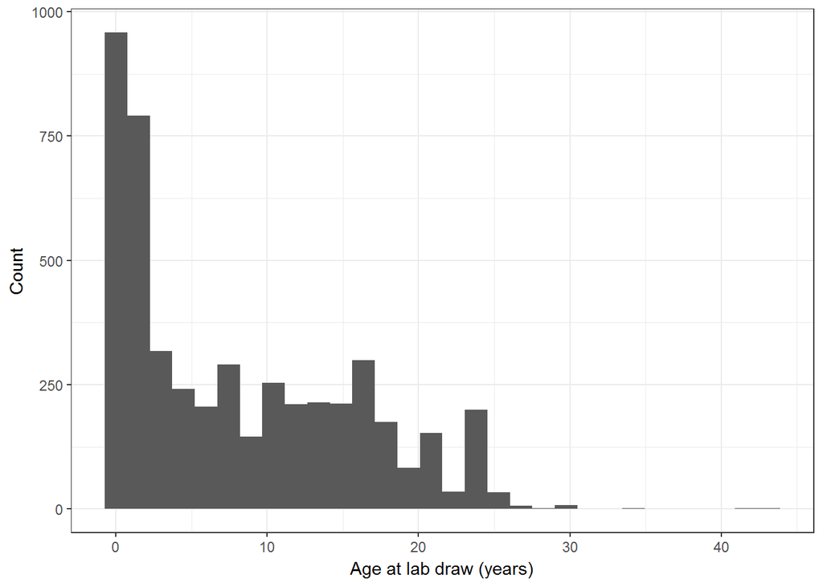

```r
hgb.age.df %>%
  ggplot() +
  geom_histogram(aes(x = AGE_AT_LAB), bins = 30) +
  xlab('Age at lab draw (years)') +
  ylab('Count') +
  theme_bw()
```

### Join to Heart Rate Data Frame

```r
hgb.vs <-
  dplyr::left_join(x = hgb.age.df,
                   y = vs.hr.df,
                   by = c('VISIT_KEY')) %>%
  dplyr::mutate(TIME_DIFF = as.numeric(SPECIMEN_TAKEN_DT - REC_DT, units='hours')) %>%
  dplyr::filter(VALUE > 1.5) %>%
  dplyr::filter(TIME_DIFF > 0 & TIME_DIFF <= 4) %>%
  dplyr::group_by(PROC_ORD_KEY, BASE_NM) %>%
  dplyr::summarize(MEAN_VS = mean(VAL),
                   HGB_VAL = VALUE[1],
                   AGE_AT_LAB = AGE_AT_LAB[1]) %>%
  dplyr::ungroup()

mid.98 <- quantile(hgb.vs$MEAN_VS, c(0.01, 0.99), na.rm = T)

hgb.vs <-
  hgb.vs %>%
  dplyr::filter(MEAN_VS >= mid.98[1] & MEAN_VS <= mid.98[2])
```

What’s the histogram of the Hgb values look like?

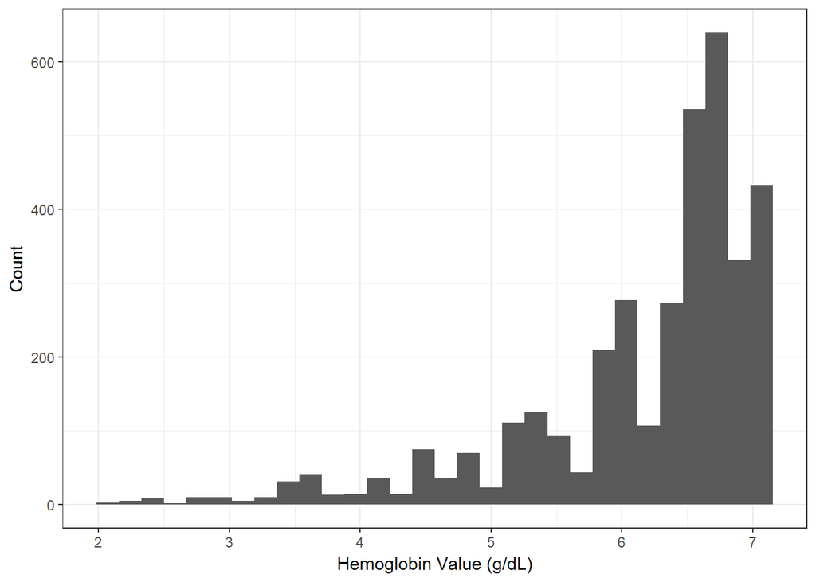

```r
hgb.vs %>%
  ggplot() +
  geom_histogram(aes(x = HGB_VAL)) +
  xlab('Hemoglobin Value (g/dL)') +
  ylab('Count') +
  theme_bw()
```

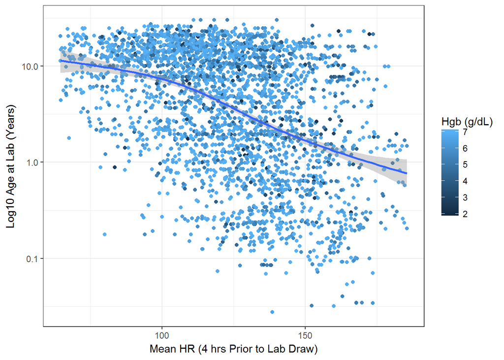

```r
hgb.vs %>%
  ggplot() +
  geom_point(aes(x = MEAN_VS, y = AGE_AT_LAB, color = HGB_VAL)) +
  geom_smooth(aes(x = MEAN_VS, y = AGE_AT_LAB)) +
  #geom_density2d(aes(x = VAL, y = AGE_AT_LAB), alpha = 0.5) +
  scale_y_log10() +
  xlab('Mean HR (4 hrs Prior to Lab Draw)') +
  ylab('Log10 Age at Lab (Years)') +
  labs(color = 'Hgb (g/dL)') +
  theme_bw()
```

Can we predict Hgb based on HR and age?

```r
model <- lm(HGB_VAL ~ AGE_AT_LAB + MEAN_VS, data = hgb.vs)

summary(model)
```

```
##
## Call:
## lm(formula = HGB_VAL ~ AGE_AT_LAB + MEAN_VS, data = hgb.vs)
##
## Residuals:
##     Min      1Q  Median      3Q     Max
## -4.1969 -0.3118  0.3086  0.6391  1.1213
##
## Coefficients:
##               Estimate Std. Error t value Pr(>|t|)
## (Intercept)  6.7855406  0.0928831  73.055  < 2e-16 ***
## AGE_AT_LAB  -0.0080355  0.0022937  -3.503 0.000465 ***
## MEAN_VS     -0.0044553  0.0006745  -6.606 4.54e-11 ***
## ---
## Signif. codes:  0 '***' 0.001 '**' 0.01 '*' 0.05 '.' 0.1 ' ' 1
##
## Residual standard error: 0.905 on 3586 degrees of freedom
## Multiple R-squared:  0.01239,    Adjusted R-squared:  0.01184
## F-statistic: 22.49 on 2 and 3586 DF,  p-value: 1.958e-10
```

> For each 10-point increase in HR comes a 0.044 g/dL decrement in hemoglobin, starting at an intercept of 6.79 g/dL.